# solution

### Imports

```python
import pandas as pd
from datetime import datetime, timedelta
import matplotlib.pyplot as plt
import numpy as np
from math import log
import json
from random import randint

# keras imports for neural network
from keras.models import Sequential, load_model
from keras.layers import Dense, Dropout
from keras import optimizers
```

**Load and check data**

```python
kick_start = pd.read_csv('data.csv')
kick_start.head()
```

|  | ID | name | category | main_category | currency | deadline | goal | launched | pledged | state | backers | country | usd pledged | usd_pledged_real | usd_goal_real |
| --- | --- | --- | --- | --- | --- | --- | --- | --- | --- | --- | --- | --- | --- | --- | --- |
| 0 | 1000002330 | The Songs of Adelaide & Abullah | Poetry | Publishing | GBP | 2015-10-09 | 1000.0 | 2015-08-11 12:12:28 | 0.0 | failed | 0 | GB | 0.0 | 0.0 | 1533.95 |
| 1 | 1000003930 | Greeting From Earth: ZGAC Arts Capsule For ET | Narrative Film | Film & Video | USD | 2017-11-01 | 30000.0 | 2017-09-02 04:43:57 | 2421.0 | failed | 15 | US | 100.0 | 2421.0 | 30000.00 |
| 2 | 1000004038 | Where is Hank? | Narrative Film | Film & Video | USD | 2013-02-26 | 45000.0 | 2013-01-12 00:20:50 | 220.0 | failed | 3 | US | 220.0 | 220.0 | 45000.00 |
| 3 | 1000007540 | ToshiCapital Rekordz Needs Help to Complete Album | Music | Music | USD | 2012-04-16 | 5000.0 | 2012-03-17 03:24:11 | 1.0 | failed | 1 | US | 1.0 | 1.0 | 5000.00 |
| 4 | 1000011046 | Community Film Project: The Art of Neighborhoo... | Film & Video | Film & Video | USD | 2015-08-29 | 19500.0 | 2015-07-04 08:35:03 | 1283.0 | canceled | 14 | US | 1283.0 | 1283.0 | 19500.00 |

```python
kick_start.info()
```

```
<class 'pandas.core.frame.DataFrame'>
RangeIndex: 378661 entries, 0 to 378660
Data columns (total 15 columns):
ID                  378661 non-null int64
name                378657 non-null object
category            378661 non-null object
main_category       378661 non-null object
currency            378661 non-null object
deadline            378661 non-null object
goal                378661 non-null float64
launched            378661 non-null object
pledged             378661 non-null float64
state               378661 non-null object
backers             378661 non-null int64
country             378661 non-null object
usd pledged         374864 non-null float64
usd_pledged_real    378661 non-null float64
usd_goal_real       378661 non-null float64
dtypes: float64(5), int64(2), object(8)
memory usage: 43.3+ MB
```

```python
kick_start["state"].unique()
```

```
array(['failed', 'canceled', 'successful', 'live', 'undefined',
       'suspended'], dtype=object)
```

**Let's also check the distribution of the target field**

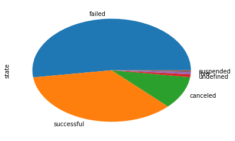

```python
pd.value_counts(kick_start['state']).plot.pie()
```

### Analyses, assumptions and visualizations

**My first assumption is that the "state" will correlate well with the number of days between "launch" and "deadline"**  
So, I convert those dates and bring them to "No. of days" format

```python
x = pd.to_datetime(kick_start["deadline"])
y = pd.to_datetime(kick_start["launched"])
z = x - y

print (z.min())
print (z.mean())
print (z.max())
```

```
0 days 00:07:17
33 days 21:58:10.533968
16738 days 23:00:00
```

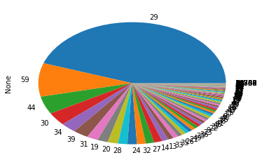

```python
num_days = z.apply(lambda x: str(x.days))
pd.value_counts(num_days).plot.pie()
```

**Most projects seem to have a deadline of 29 days (~1 month), followed by 59 days (~2 months) etc.**

### Overall Strategy

I will select certain fields (mostly categorical) to feed to a Decision Tree model to reduce entropy in the data. This will also include the "No. of days to deadline" computed above.

If the decision tree returns some good results and is able to reduce entropy by looking at just the categorical data (**without the $amounts, backers etc.** ), I will output the probability distribution of states as the "partial" predictions from this tree.

In the last stage, I will concatenate these partial predictions with the rest of the columns ($amounts, backers etc.) to create a "feature vector".  
This feature vector would then go as inputs to a neural network for further training.

So, even while testing, predictions will be broken down to two parts, first to recieve partial predictions from the decision tree and then to get the final predictions from the neural network.

**The intuition is to use the Decision Tree to handle entropy in the categorical data and reduce the non-linearity / dimensions for the neural network to achieve better learning.**

Since I need the probability distributions from the decision tree, I am implementing a decision tree based on ID3 algorithm for this purpose.

### Fields selected for decision tree :

- category
- main_category
- currency
- country
- Number of days to deadline

**The "id" and "name" fields will be omitted as I don't think there is much correlation between these fields and the "state"**

```python
dt_kstart = kick_start[['category', 'main_category', 'currency', 'country', 'state']]
dt_kstart['num_days'] = num_days
```

```python
dt_kstart.state.value_counts()
```

```
failed        197719
successful    133956
canceled       38779
undefined       3562
live            2799
suspended       1846
Name: state, dtype: int64
```

```python
# this function calculates the probability distribution of the unique items for a specified column in a dataframe
def get_probabilities(df, column):
    freqs = df[column].value_counts()
    summation = sum(freqs)
    probabilities = freqs / summation
    return (probabilities)

# function to return log base 2
def ln(x):
    return log(x)/log(2)

# to return the entropy given the probability distribution
def get_entropy(probabilities):
    return sum( probabilities * probabilities.apply(ln)) * -1
```

```python
get_entropy(get_probabilities(dt_kstart, 'state'))
```

```
1.5096218422351115
```

```python
dt_kstart.head()
```

|  | category | main_category | currency | country | state | num_days |
| --- | --- | --- | --- | --- | --- | --- |
| 0 | Poetry | Publishing | GBP | GB | failed | 58 |
| 1 | Narrative Film | Film & Video | USD | US | failed | 59 |
| 2 | Narrative Film | Film & Video | USD | US | failed | 44 |
| 3 | Music | Music | USD | US | failed | 29 |
| 4 | Film & Video | Film & Video | USD | US | canceled | 55 |

```python
# splitting a data-frame, on and index/column and value
# returns the new dataframe after the split
def split_data(df, column, value):
    return df[df[column] == value]

# to get the best feature based on information gain
def get_best_feature(df, target):
    initial_entropy = get_entropy(get_probabilities(df, target))
    best_gain = 0.0
    best_feature = None
    feature_list = list(df.columns)
    feature_list.remove(target)
    for feature in feature_list:
        uniques = df[feature].unique()
        new_entropy = 0
        for value in uniques:
            subset =  split_data (df, feature, value)
            probability = len(subset) / len(df)
            new_entropy += probability * get_entropy(get_probabilities(subset, target))
        info_gain = initial_entropy - new_entropy
        #print (info_gain, feature)
        if info_gain > best_gain:
            best_gain = info_gain
            best_feature = feature

    return best_feature
```

```python
get_best_feature(dt_kstart, 'state')
```

[output not shown]

```
'category'
```

# Looks like, my assumption that num_days would be highly correlated with state, is wrong!

Nonetheless, there is some correlation and some information gain.

We now proceed to build the Decision Tree

Though the output of this decision tree is a probability distribution, I still label it as 'state' so that it is easier to retreive predictions from this tree later.

```python
# returns true if there is only one label in the target field
def is_pure(df, target):
    return len(df[target].unique()) == 1

def create_tree(df, target):
    if is_pure(df, target):
        return {'state' : dict(get_probabilities(df, target))}
    if len(df.columns) <= 2:
        features = list(df.columns)
        features.remove(target)
        feature = features[0]
        leaf_node = {feature:{}}
        uniques = df[feature].unique()
        for value in uniques:
            subset = split_data(df, feature, value)
            leaf_node[feature][value] = {'state' : dict(get_probabilities(subset, target))}
        return leaf_node

    best_feature = get_best_feature(df, target)
    if best_feature:
        my_tree = {best_feature:{}}
        uniques = df[best_feature].unique()
        for value in uniques:
            subset = split_data(df, best_feature, value)
            subset = subset.drop(best_feature, axis=1)
            my_tree[best_feature][value] = create_tree(subset, target)
    else:
        my_tree = {'state' : dict(get_probabilities(df, target))}

    return my_tree
```

```python
# creating this tree takes ~10 minutes
d_tree = create_tree(dt_kstart, 'state')
```

```python
# saving the dictionary
filename = 'decision_tree_2.txt'

with open(filename, 'w') as f:
    json.dump(d_tree, f)
```

```python
def load_tree(filename):
    with open(filename, 'r') as f:
        return json.load(f)

d_tree = load_tree('decision_tree_2.txt')
```

```python
# to predict using the decision tree
def partial_predict(tree, features):
    probabs = {}
    first_dict = next(iter(tree))
    second_dict = tree[first_dict]
    feat_value = features[first_dict]
    if first_dict != 'state':
        for key in second_dict.keys():
            if feat_value == key:
                probabs = partial_predict(second_dict[key], features)
    else:
        probabs = second_dict
    return probabs
```

## Testing the tree

```python
labels = dict(dt_kstart.loc[11])
labels
```

```
{'category': 'Indie Rock',
 'country': 'US',
 'currency': 'USD',
 'main_category': 'Music',
 'num_days': '29',
 'state': 'successful'}
```

```python
partial_predict(d_tree, labels)
```

```
{'canceled': 0.04667949951876805,
 'failed': 0.28873917228103946,
 'live': 0.002406159769008662,
 'successful': 0.6616939364773821,
 'suspended': 0.00048123195380173246}
```

```python
# retrieving data from the tree
d_tree['category']['Indie Rock']['num_days']['29']['country']['US']
```

```
{'state': {'canceled': 0.04667949951876805,
  'failed': 0.28873917228103946,
  'live': 0.002406159769008662,
  'successful': 0.6616939364773821,
  'suspended': 0.00048123195380173246}}
```

## Generating probability distributions from categories for the entire dataset using the tree

```python
kick_start['state'].unique()
```

```
array(['failed', 'canceled', 'successful', 'live', 'undefined',
       'suspended'], dtype=object)
```

```python
# to translate a predicted distribution (a dictionary) to its corresponding numpy version
def translate(distribution):
    array = np.empty([6])
    # to hardcode positions in the numpy array
    positions = {'failed':0, 'successful':1, 'canceled':2, 'undefined':3, 'live':4, 'suspended':5}
    for key in positions:
        if key in distribution.keys():
            array[positions[key]] = distribution[key]
        else:
            array[positions[key]] = 0
    return array
```

```python
x = partial_predict(d_tree, labels) #same example as above
```

```python
x
```

```
{'canceled': 0.04667949951876805,
 'failed': 0.28873917228103946,
 'live': 0.002406159769008662,
 'successful': 0.6616939364773821,
 'suspended': 0.00048123195380173246}
```

```python
y = translate(x)
print (y) # this is now translated to a numpy version
```

```
[2.88739172e-01 6.61693936e-01 4.66794995e-02 0.00000000e+00
 2.40615977e-03 4.81231954e-04]
```

```python
# since this is a probability distribution, all entries must sum to 1
y.sum()
```

```
1.0
```

```python
to_predict = dt_kstart
```

```python
# to get partial predictions from the categorical data in the entire dataframe
def get_partial_predictions(tree, inputs):
    partial_predictions = []
    for i in range(len(inputs)):
        features = dict(inputs.loc[i])
        probabs = partial_predict(tree, features)
        arr = translate(probabs)
        partial_predictions.append(arr)
    return np.array(partial_predictions)
```

```python
# takes about 3 mins
part_predict = get_partial_predictions(d_tree, to_predict)
```

```python
part_predict.shape
```

```
(378661, 6)
```

```python
part_predict[:10]
```

```
array([[1.        , 0.        , 0.        , 0.        , 0.        ,
        0.        ],
       [0.66141732, 0.20866142, 0.12598425, 0.        , 0.0019685 ,
        0.0019685 ],
       [0.57037037, 0.2962963 , 0.13333333, 0.        , 0.        ,
        0.        ],
       [0.48404255, 0.4587766 , 0.04942376, 0.        , 0.00443262,
        0.00332447],
       [0.6       , 0.26666667, 0.13333333, 0.        , 0.        ,
        0.        ],
       [0.67346939, 0.24489796, 0.06122449, 0.        , 0.        ,
        0.02040816],
       [0.6       , 0.31111111, 0.08888889, 0.        , 0.        ,
        0.        ],
       [0.72881356, 0.1779661 , 0.07627119, 0.        , 0.01694915,
        0.        ],
       [0.41907152, 0.38644918, 0.17691343, 0.        , 0.00752823,
        0.01003764],
       [0.54855592, 0.35995348, 0.08819539, 0.        , 0.0021322 ,
        0.00116302]])
```

## part_predict now contains the partial predictions from the decision tree for the entire dataset

## We now prepare the training dataset for the neural network

As was mentioned earlier, this neural network needs the probably distributions from the decision tree and the remaining float columns.

So the inputs to the tree would be:

- Probability Distributions from the decision tree (length = 6)
- backers
- usd_pledged_real
- usd_goal_real

I am omitting the other columns for "pledged" and "goal" as they may contain different 'currencies' which has already been handled by the decision tree.

```python
kick_start.loc[:9]
```

|  | ID | name | category | main_category | currency | deadline | goal | launched | pledged | state | backers | country | usd pledged | usd_pledged_real | usd_goal_real |
| --- | --- | --- | --- | --- | --- | --- | --- | --- | --- | --- | --- | --- | --- | --- | --- |
| 0 | 1000002330 | The Songs of Adelaide & Abullah | Poetry | Publishing | GBP | 2015-10-09 | 1000.0 | 2015-08-11 12:12:28 | 0.00 | failed | 0 | GB | 0.00 | 0.00 | 1533.95 |
| 1 | 1000003930 | Greeting From Earth: ZGAC Arts Capsule For ET | Narrative Film | Film & Video | USD | 2017-11-01 | 30000.0 | 2017-09-02 04:43:57 | 2421.00 | failed | 15 | US | 100.00 | 2421.00 | 30000.00 |
| 2 | 1000004038 | Where is Hank? | Narrative Film | Film & Video | USD | 2013-02-26 | 45000.0 | 2013-01-12 00:20:50 | 220.00 | failed | 3 | US | 220.00 | 220.00 | 45000.00 |
| 3 | 1000007540 | ToshiCapital Rekordz Needs Help to Complete Album | Music | Music | USD | 2012-04-16 | 5000.0 | 2012-03-17 03:24:11 | 1.00 | failed | 1 | US | 1.00 | 1.00 | 5000.00 |
| 4 | 1000011046 | Community Film Project: The Art of Neighborhoo... | Film & Video | Film & Video | USD | 2015-08-29 | 19500.0 | 2015-07-04 08:35:03 | 1283.00 | canceled | 14 | US | 1283.00 | 1283.00 | 19500.00 |
| 5 | 1000014025 | Monarch Espresso Bar | Restaurants | Food | USD | 2016-04-01 | 50000.0 | 2016-02-26 13:38:27 | 52375.00 | successful | 224 | US | 52375.00 | 52375.00 | 50000.00 |
| 6 | 1000023410 | Support Solar Roasted Coffee & Green Energy! ... | Food | Food | USD | 2014-12-21 | 1000.0 | 2014-12-01 18:30:44 | 1205.00 | successful | 16 | US | 1205.00 | 1205.00 | 1000.00 |
| 7 | 1000030581 | Chaser Strips. Our Strips make Shots their B*tch! | Drinks | Food | USD | 2016-03-17 | 25000.0 | 2016-02-01 20:05:12 | 453.00 | failed | 40 | US | 453.00 | 453.00 | 25000.00 |
| 8 | 1000034518 | SPIN - Premium Retractable In-Ear Headphones w... | Product Design | Design | USD | 2014-05-29 | 125000.0 | 2014-04-24 18:14:43 | 8233.00 | canceled | 58 | US | 8233.00 | 8233.00 | 125000.00 |
| 9 | 100004195 | STUDIO IN THE SKY - A Documentary Feature Film... | Documentary | Film & Video | USD | 2014-08-10 | 65000.0 | 2014-07-11 21:55:48 | 6240.57 | canceled | 43 | US | 6240.57 | 6240.57 | 65000.00 |

## We first concatenate the partial prediction to the remaining (numeric) fields in the dataset

```python
nn_train_part1 = part_predict
nn_train_part2 = np.array(kick_start[['backers', 'usd_pledged_real', 'usd_goal_real']])

print (nn_train_part1.shape)
print (nn_train_part2.shape)
```

```
(378661, 6)
(378661, 3)
```

```python
nn_inputs = np.concatenate((nn_train_part1, nn_train_part2), axis=1)
```

```python
nn_inputs.shape
```

```
(378661, 9)
```

```python
nn_inputs[:10]
```

```
array([[1.00000000e+00, 0.00000000e+00, 0.00000000e+00, 0.00000000e+00,
        0.00000000e+00, 0.00000000e+00, 0.00000000e+00, 0.00000000e+00,
        1.53395000e+03],
       [6.61417323e-01, 2.08661417e-01, 1.25984252e-01, 0.00000000e+00,
        1.96850394e-03, 1.96850394e-03, 1.50000000e+01, 2.42100000e+03,
        3.00000000e+04],
       [5.70370370e-01, 2.96296296e-01, 1.33333333e-01, 0.00000000e+00,
        0.00000000e+00, 0.00000000e+00, 3.00000000e+00, 2.20000000e+02,
        4.50000000e+04],
       [4.84042553e-01, 4.58776596e-01, 4.94237589e-02, 0.00000000e+00,
        4.43262411e-03, 3.32446809e-03, 1.00000000e+00, 1.00000000e+00,
        5.00000000e+03],
       [6.00000000e-01, 2.66666667e-01, 1.33333333e-01, 0.00000000e+00,
        0.00000000e+00, 0.00000000e+00, 1.40000000e+01, 1.28300000e+03,
        1.95000000e+04],
       [6.73469388e-01, 2.44897959e-01, 6.12244898e-02, 0.00000000e+00,
        0.00000000e+00, 2.04081633e-02, 2.24000000e+02, 5.23750000e+04,
        5.00000000e+04],
       [6.00000000e-01, 3.11111111e-01, 8.88888889e-02, 0.00000000e+00,
        0.00000000e+00, 0.00000000e+00, 1.60000000e+01, 1.20500000e+03,
        1.00000000e+03],
       [7.28813559e-01, 1.77966102e-01, 7.62711864e-02, 0.00000000e+00,
        1.69491525e-02, 0.00000000e+00, 4.00000000e+01, 4.53000000e+02,
        2.50000000e+04],
       [4.19071518e-01, 3.86449184e-01, 1.76913425e-01, 0.00000000e+00,
        7.52823087e-03, 1.00376412e-02, 5.80000000e+01, 8.23300000e+03,
        1.25000000e+05],
       [5.48555922e-01, 3.59953479e-01, 8.81953867e-02, 0.00000000e+00,
        2.13219616e-03, 1.16301609e-03, 4.30000000e+01, 6.24057000e+03,
        6.50000000e+04]])
```

```python
#save the training_inputs for the neural network
np.save('nn_inputs', nn_inputs)
```

```python
# for the targets of the neural network
states = np.array(kick_start['state'])
states.shape
```

```
(378661,)
```

```python
# to translate the state into integers for one-hot encoding
def translate_states(states):
    array = np.empty([len(states)], dtype = 'int8')
    positions = {'failed':0, 'successful':1, 'canceled':2, 'undefined':3, 'live':4, 'suspended':5}
    for i, state in enumerate(list(states)):
        array[i] = int(positions[state])
    return array
```

```python
translated = translate_states(states)
translated[0]
```

```
0
```

```python
# One hot encoding
nb_classes = 6
one_hot_targets = np.eye(nb_classes)[translated]
```

```python
one_hot_targets[:10]
```

```
array([[1., 0., 0., 0., 0., 0.],
       [1., 0., 0., 0., 0., 0.],
       [1., 0., 0., 0., 0., 0.],
       [1., 0., 0., 0., 0., 0.],
       [0., 0., 1., 0., 0., 0.],
       [0., 1., 0., 0., 0., 0.],
       [0., 1., 0., 0., 0., 0.],
       [1., 0., 0., 0., 0., 0.],
       [0., 0., 1., 0., 0., 0.],
       [0., 0., 1., 0., 0., 0.]])
```

```python
# saving the targets for the neural network
np.save('one_hot_targets', one_hot_targets)
```

## We now have our inputs in "nn_inputs" and out targets in "one_hot_targets".

**Training the Neural Network**

```python
inputs = np.load('nn_inputs.npy')
targets = np.load('one_hot_targets.npy')
```

```python
model = Sequential()
model.add(Dense(9, input_dim=9, activation='sigmoid'))
model.add(Dense(20, activation='sigmoid'))
model.add(Dense(20, activation='sigmoid'))
model.add(Dense(10, activation='sigmoid'))
model.add(Dense(6, activation = 'softmax'))
```

```python
model.compile(loss='binary_crossentropy', optimizer='nadam', metrics=['accuracy'])
```

```python
model.fit(nn_inputs, one_hot_targets, validation_split = 0.2, epochs = 12, batch_size=200)
```

```
Train on 302928 samples, validate on 75733 samples
```

```
<keras.callbacks.History at 0x1e02a4bbf28>
```

```python
model.save('nn_model.h5')
```

```python
# helper function to convert dates to num_days
def convert_dates(features):
    x = pd.to_datetime(features["deadline"])
    y = pd.to_datetime(features["launched"])
    z = x - y
    num_days = str(z.days)
    return num_days

# inputs: a pandas.Series object for final predictions using bot the decision tree and the neural network
def predict(features, d_tree, model):
    expected_out = one_hot = None
    reverse_hot = {0:'failed', 1:'successful', 2:'canceled', 3:'undefined', 4:'live', 5:'suspended'}
    num_days = convert_dates(features)
    features = dict(features)
    features['num_days'] = num_days
    part_preds = partial_predict(d_tree, features)
    part1 = translate(part_preds)
    part2 = np.array([features['backers'], features['usd_pledged_real'], features['usd_goal_real']])
    to_predict = np.concatenate((part1, part2))
    expected_out = features['state']
    to_predict = np.array([to_predict])
    predicted = model.predict(to_predict)
    out = predicted.argmax()
    out = reverse_hot[out]
    return [out, expected_out]
```

```python
# test an i'th row in the dataset
def get_prediction(i):
    return predict(kick_start.loc[i], d_tree, model)

print (get_prediction(randint(0,1000)))
print (get_prediction(randint(0,5000)))
```

```
['successful', 'successful']
['failed', 'failed']
```

## Testing with the entire dataset

```python
# predicting all records takes about 11 mins
results = []
for i in range(len(kick_start)):
    results.append(predict(kick_start.loc[i], d_tree, model))
```

```python
results[:50]
```

```
[['failed', 'failed'],
 ['failed', 'failed'],
 ['failed', 'failed'],
 ['failed', 'failed'],
 ['failed', 'canceled'],
 ['successful', 'successful'],
 ['successful', 'successful'],
 ['failed', 'failed'],
 ['failed', 'canceled'],
 ['failed', 'canceled'],
 ['failed', 'failed'],
 ['successful', 'successful'],
 ['failed', 'failed'],
 ['failed', 'failed'],
 ['successful', 'successful'],
 ['failed', 'failed'],
 ['failed', 'failed'],
 ['failed', 'failed'],
 ['successful', 'successful'],
 ['failed', 'failed'],
 ['successful', 'successful'],
 ['failed', 'failed'],
 ['failed', 'failed'],
 ['failed', 'failed'],
 ['successful', 'successful'],
 ['successful', 'successful'],
 ['failed', 'failed'],
 ['successful', 'successful'],
 ['successful', 'successful'],
 ['successful', 'successful'],
 ['failed', 'failed'],
 ['successful', 'successful'],
 ['successful', 'successful'],
 ['failed', 'failed'],
 ['successful', 'successful'],
 ['failed', 'failed'],
 ['successful', 'successful'],
 ['successful', 'successful'],
 ['failed', 'failed'],
 ['successful', 'successful'],
 ['failed', 'live'],
 ['successful', 'successful'],
 ['successful', 'successful'],
 ['failed', 'failed'],
 ['successful', 'successful'],
 ['failed', 'failed'],
 ['successful', 'successful'],
 ['successful', 'successful'],
 ['successful', 'successful'],
 ['failed', 'failed']]
```

```python
with open('results.txt', 'w') as f:
    json.dump(results, f)
```

```python
predicted = [x[0] for x in results]
expected = [x[1] for x in results]

d = {'predicted': predicted, 'expected':expected}
```

```python
result_df = pd.DataFrame(d, columns=['predicted', 'expected'])
```

```python
len(result_df)
```

```
378661
```

```python
matches = result_df.loc[(result_df['predicted'] == result_df['expected'])]
```

```python
len(matches)
```

```
331638
```

```python
true_positive_percentage = len(matches)/len(result_df)
```

```python
true_positive_percentage
```

```
0.8758176838913962
```

```python
false_negatives =  result_df.loc[(result_df['predicted'] != result_df['expected'])]
```

```python
len(false_negatives)
```

```
47023
```

```python
false_negative_percentages = len(false_negatives) / len(result_df)
```

```python
false_negative_percentages
```

```
0.12418231610860374
```

# OVERALL RESULTS ON THE ENTIRE TRAINING DATASET

## True Positive Count = 331638 | True Positive Percentage = 87.5 %

## False Negative Count = 47023 | False Negative Percentage = 12.4 %

# FOUND ANOTHER FILE IN THE KAGGLE DATASET !!

## I choose to load this file as the TEST dataset to test the paired models

## **There's a catch :**

## Unlike the training dataset, this test dataset does not have currency converted columns

## So, I will select only the 'USD' currency rows for the test

```python
test = pd.read_csv('test_2.csv', encoding = 'ISO-8859-1')
```

```python
test.head()
```

|  | ID | name | category | main_category | currency | deadline | goal | launched | pledged | state | backers | country | usd pledged | Unnamed: 13 | Unnamed: 14 | Unnamed: 15 | Unnamed: 16 |
| --- | --- | --- | --- | --- | --- | --- | --- | --- | --- | --- | --- | --- | --- | --- | --- | --- | --- |
| 0 | 1000002330 | The Songs of Adelaide & Abullah | Poetry | Publishing | GBP | 2015-10-09 11:36:00 | 1000 | 2015-08-11 12:12:28 | 0 | failed | 0 | GB | 0 | NaN | NaN | NaN | NaN |
| 1 | 1000004038 | Where is Hank? | Narrative Film | Film & Video | USD | 2013-02-26 00:20:50 | 45000 | 2013-01-12 00:20:50 | 220 | failed | 3 | US | 220 | NaN | NaN | NaN | NaN |
| 2 | 1000007540 | ToshiCapital Rekordz Needs Help to Complete Album | Music | Music | USD | 2012-04-16 04:24:11 | 5000 | 2012-03-17 03:24:11 | 1 | failed | 1 | US | 1 | NaN | NaN | NaN | NaN |
| 3 | 1000011046 | Community Film Project: The Art of Neighborhoo... | Film & Video | Film & Video | USD | 2015-08-29 01:00:00 | 19500 | 2015-07-04 08:35:03 | 1283 | canceled | 14 | US | 1283 | NaN | NaN | NaN | NaN |
| 4 | 1000014025 | Monarch Espresso Bar | Restaurants | Food | USD | 2016-04-01 13:38:27 | 50000 | 2016-02-26 13:38:27 | 52375 | successful | 224 | US | 52375 | NaN | NaN | NaN | NaN |

### The columns need cleaning (undo trailing space) and some manipulation (convert 'usd_pledged' to 'usd_pledged_real' | convert 'goal' to 'usd_goal_real')

```python
test.columns = ['ID', 'name', 'category', 'main_category', 'currency', 'deadline',
       'usd_goal_real', 'launched', 'pledged', 'state', 'backers', 'country',
       'usd_pledged_real', 'Unnamed: 13', 'Unnamed: 14', 'Unnamed: 15',
       'Unnamed: 16']
```

```python
test_us = test[(test['currency'] == 'USD')]
```

```python
test_us.head()
```

|  | ID | name | category | main_category | currency | deadline | usd_goal_real | launched | pledged | state | backers | country | usd_pledged_real | Unnamed: 13 | Unnamed: 14 | Unnamed: 15 | Unnamed: 16 |
| --- | --- | --- | --- | --- | --- | --- | --- | --- | --- | --- | --- | --- | --- | --- | --- | --- | --- |
| 1 | 1000004038 | Where is Hank? | Narrative Film | Film & Video | USD | 2013-02-26 00:20:50 | 45000 | 2013-01-12 00:20:50 | 220 | failed | 3 | US | 220 | NaN | NaN | NaN | NaN |
| 2 | 1000007540 | ToshiCapital Rekordz Needs Help to Complete Album | Music | Music | USD | 2012-04-16 04:24:11 | 5000 | 2012-03-17 03:24:11 | 1 | failed | 1 | US | 1 | NaN | NaN | NaN | NaN |
| 3 | 1000011046 | Community Film Project: The Art of Neighborhoo... | Film & Video | Film & Video | USD | 2015-08-29 01:00:00 | 19500 | 2015-07-04 08:35:03 | 1283 | canceled | 14 | US | 1283 | NaN | NaN | NaN | NaN |
| 4 | 1000014025 | Monarch Espresso Bar | Restaurants | Food | USD | 2016-04-01 13:38:27 | 50000 | 2016-02-26 13:38:27 | 52375 | successful | 224 | US | 52375 | NaN | NaN | NaN | NaN |
| 5 | 1000023410 | Support Solar Roasted Coffee & Green Energy! ... | Food | Food | USD | 2014-12-21 18:30:44 | 1000 | 2014-12-01 18:30:44 | 1205 | successful | 16 | US | 1205 | NaN | NaN | NaN | NaN |

```python
len(test_us)
```

```
260298
```

## I can now use this data for the testing

```python
model = load_model('nn_model.h5')
```

```python
def load_tree(filename):
    with open(filename, 'r') as f:
        return json.load(f)
```

```python
d_tree = load_tree('decision_tree_2.txt')
```

```python
results = []
for index, row in test_us.iterrows():
    results.append(predict(row, d_tree, model))
```

```python
# printing data from results

predicted = [x[0] for x in results]
expected = [x[1] for x in results]

d = {'predicted': predicted, 'expected':expected}

result_df = pd.DataFrame(d, columns=['predicted', 'expected'])
matches = result_df.loc[(result_df['predicted'] == result_df['expected'])]
match_percentage = len(matches)/len(result_df)
false_negatives =  result_df.loc[(result_df['predicted'] != result_df['expected'])]
fail_percentage = len(false_negatives) / len(result_df)

print(match_percentage)
print(fail_percentage)
```

```
0.8647626950648871
0.13523730493511282
```

# THE ACCURACY NOW IS 86.47%